# 聚类方法回顾1

wzy

2018年3月14日

今天的实验主要是对R语言实现聚类算法的回顾。可用于复习的书和章节有： - 《复杂数据统计方法——基于R的应用》8.1.2 - 《数据挖掘：R语言实战》

# 《复杂数据统计方法——基于R的应用》8.1.2

## 聚类数目的选择

### 方法一

- cluster包的函数clusGap()计算聚类度量的优度，即Gap统计量。
- 对每个类数目k，它比较ln(W(k))和E*[ln(W(k))]，后者由自主罚定义，根据参考分布来做模拟。
- 寻找最大值之所在要利用“1-SE准则”，寻求使得局部最大值在一个标准误差值内的最小的k。

```r
library(cluster)
library(ICGE)
library(ggmap)
names(faithful)
```

```
## [1] "eruptions" "waiting"
```

```r
(z <- clusGap(faithful,FUN=kmeans,10))
```

```
## Clustering Gap statistic ["clusGap"] from call:
## clusGap(x = faithful, FUNcluster = kmeans, K.max = 10)
## B=100 simulated reference sets, k = 1..10; spaceH0="scaledPCA"
##  --> Number of clusters (method 'firstSEmax', SE.factor=1): 2
##           logW   E.logW        gap     SE.sim
##  [1,] 6.953597 7.094707 0.14111070 0.02611020
##  [2,] 6.096229 6.405822 0.30959292 0.02619114
##  [3,] 5.796955 6.002571 0.20561582 0.02789064
##  [4,] 5.634835 5.724140 0.08930424 0.02660218
##  [5,] 5.348031 5.521101 0.17306988 0.02971457
##  [6,] 5.230656 5.356180 0.12552399 0.02973807
##  [7,] 5.101708 5.236238 0.13453031 0.04523304
##  [8,] 4.893632 5.119205 0.22557274 0.04544182
##  [9,] 4.913184 5.017864 0.10468034 0.05100722
## [10,] 4.723410 4.932075 0.20866537 0.04100415
```

Number of clusters (method ‘firstSEmax’, SE.factor=1): 2

说明利用firstSEmax方法选择2个类

可以对Gap统计量画出图来，并利用后面要介绍的k均值聚类来点出对于faithful数据分类的效果图。 这里所用的k均值聚类方法为程序包cluster中的函数pam()，它比通常的K均值聚类方法更加稳健。

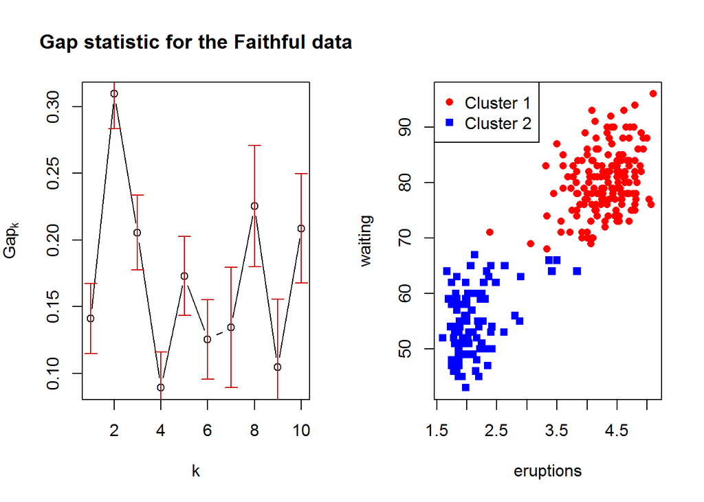

```r
a <- pam(faithful,2)
par(mfrow=c(1,2))
plot(z,main="Gap statistic for the Faithful data")
plot(faithful,col=4,type="n")
points(faithful[a$clust==1,],col=2,pch=16)
points(faithful[a$clust==2,],col=4,pch=15)
legend("topleft",c("Cluster 1","Cluster 2"),col=c(2,4),pch=16:15)
```

### 方法二

利用所谓的INCA指数。所用的程序包为ICGE。

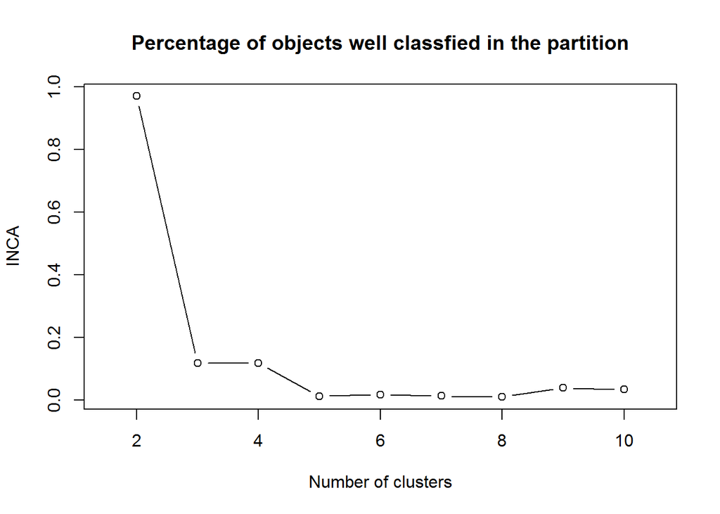

```r
d <- dist(faithful)
T <- rep(NA,5)
for(i in 2:10){
  part <- pam(d,i)$clustering
  T[i] <- INCAindex(d,part)$Total
}
plot(T,type="b",xlab="Number of clusters",ylab="INCA",xlim=c(1.5,10.5))
title("Percentage of objects well classfied in the partition")
```

最大值点在类数取2，应该分成两类

### 例二

```r
w <- read.table("D:\\data\\复杂数据统计方法\\LA_Neighborhoods.txt",header = TRUE)
dim(w)
```

```
## [1] 110  15
```

```r
names(w)
```

```
##  [1] "LA_Nbhd"    "Income"     "Schools"    "Diversity"  "Age"
##  [6] "Homes"      "Vets"       "Asian"      "Black"      "Latino"
## [11] "White"      "Population" "Area"       "Longitude"  "Latitude"
```

```r
w$density <- w$Population/w$Area
u <- w[,-c(12:15)]
```

```r
names(u)
```

```
##  [1] "LA_Nbhd"   "Income"    "Schools"   "Diversity" "Age"
##  [6] "Homes"     "Vets"      "Asian"     "Black"     "Latino"
## [11] "White"     "density"
```

```r
(z <- clusGap(u[,-1],FUN=kmeans,20))
```

```
## Clustering Gap statistic ["clusGap"] from call:
## clusGap(x = u[, -1], FUNcluster = kmeans, K.max = 20)
## B=100 simulated reference sets, k = 1..20; spaceH0="scaledPCA"
##  --> Number of clusters (method 'firstSEmax', SE.factor=1): 1
##           logW   E.logW       gap     SE.sim
##  [1,] 13.72307 14.43127 0.7081943 0.03729780
##  [2,] 13.37089 13.83491 0.4640259 0.03378013
##  [3,] 13.02362 13.53495 0.5113337 0.03172321
##  [4,] 12.81713 13.35627 0.5391386 0.03911587
##  [5,] 12.62424 13.24147 0.6172288 0.03903031
##  [6,] 12.52588 13.15014 0.6242573 0.04263307
##  [7,] 12.47313 13.06722 0.5940911 0.04107401
##  [8,] 12.33514 12.98506 0.6499235 0.04038439
##  [9,] 12.24227 12.91236 0.6700922 0.03746723
## [10,] 12.16062 12.85519 0.6945703 0.05406555
## [11,] 12.13192 12.77890 0.6469814 0.04442261
## [12,] 12.03999 12.72795 0.6879537 0.06131858
## [13,] 11.93724 12.66479 0.7275462 0.06069613
## [14,] 11.88781 12.60507 0.7172620 0.04564807
## [15,] 11.82506 12.55442 0.7293643 0.05029015
## [16,] 11.78699 12.49967 0.7126770 0.04594839
## [17,] 11.79774 12.45894 0.6611933 0.05161945
## [18,] 11.72215 12.42081 0.6986686 0.04634513
## [19,] 11.73132 12.36907 0.6377474 0.05161701
## [20,] 11.66820 12.33865 0.6704562 0.05721970
```

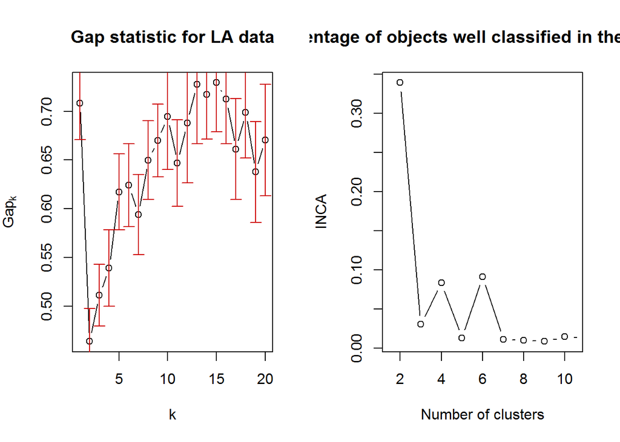

```r
d <- dist(u[,-1])
m <- 5
T <- rep(NA,m)
for(i in 2:20){
  part <- pam(d,i)$clustering
  T[i] <- INCAindex(d,part)$Total
}
par(mfrow=c(1,2))
plot(z,main="Gap statistic for LA data")
plot(T,type="b",xlab="Number of clusters",ylab="INCA",xlim=c(1.5,10.5))
title("Percentage of objects well classified in the partition")
```

从左图看，第一个局部极大值位于1，如果不选择1，最近极大值为6，而在其一个标准差之内k的最小点是5，因此可以选择5类。

从右图看，INCA指数最大值则是2.这就显示出各种方法的区别了。

## 分层聚类

聚类首先要确定点与点之间的距离，可以使用：

- 欧氏距离；
- 平方欧氏距离；
- 绝对距离；
- 夹角余弦；
- MInkowski距离等；

此外还要定义类间距离，包括：

- 最短距离法；
- 最长距离法；
- 类平均法；
- 重心法；
- 离差平方和法；

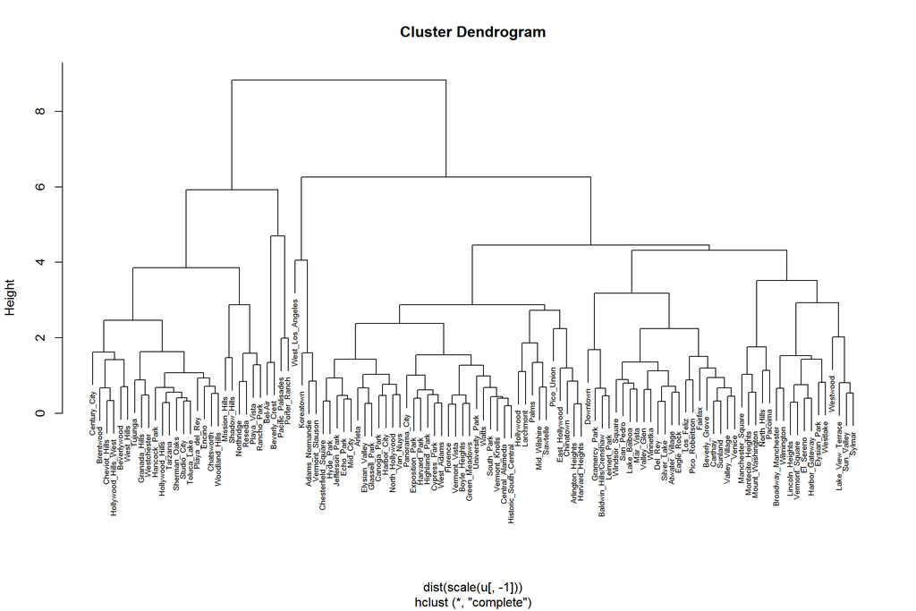

```r
w <- read.table("D:\\data\\复杂数据统计方法\\LA_Neighborhoods.txt",header = TRUE)
w <- data.frame(w,density=w$Population/w$Area)
u <- w[,c(1,2,5,6,11,16)]
# 标准化数据，聚类方法="complete"
hh <- hclust(dist(scale(u[,-1])),"complete")
plot(hh,labels=u[,1],cex=.6)
```

```r
# id <- identify(hh)
id <- load("id.rda")
```

```r
id[[1]]
```

```
## [1] "id"
```

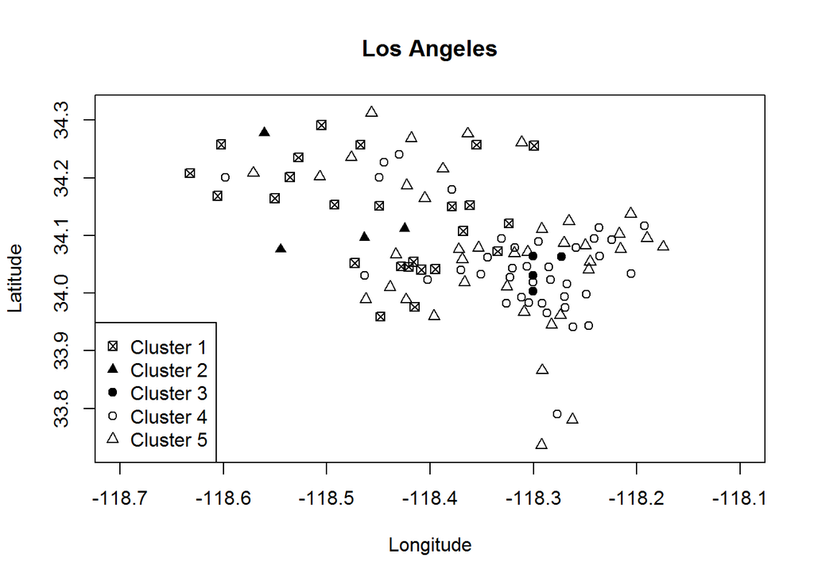

```r
load("20180315.RData")
ppp <- c(7,17,19,21,24)
plot(w[id[[1]],14:15],pch=ppp[1],col=1,xlim=c(-118.7,-118.1),ylim=c(33.73,34.32),main="Los Angeles")
for(i in 2:5)
  points(w[id[[i]],14:15],pch=ppp[i])
legend("bottomleft",pch=ppp,paste("Cluster",1:5))
```

[figure not shown]

```r
hdf <- get_map(location=c(lon=-118.1,lat=33.9))
ggmap(hdf)
```

分层聚类的树状图直观易懂，容易帮助人们理解各类的特点和关系。 其缺点是对于大数据的计算速度相对较慢。

## k均值聚类

k均值聚类的计算速度很快，缺点是必须事先选择类别的数目。

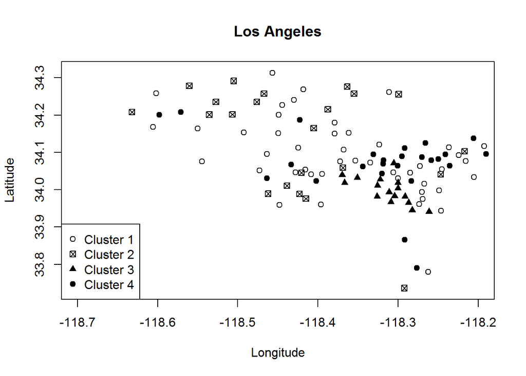

```r
w <- read.table("D:\\data\\复杂数据统计方法\\LA_Neighborhoods.txt",header = TRUE)
w$density <- w$Population/w$Area
u <- w[,-c(12:15)]
a <- kmeans(scale(u[,-1]),5)
ppp <- c(7,17,19,21)
plot(w[a$cluster==1,14:15],pch=1,col=1,xlim=c(-118.7,-118.2),ylim=c(33.73,34.32),main="Los Angeles")
for(i in 2:5)
  points(w[a$cluster==i,14:15],pch=ppp[i-1])
legend("bottomleft",pch=c(1,ppp),paste("Cluster",1:4))
```

## 含有聚类数目各种选择方法及各种聚类方法的综合程序包

该程序包为NbClust

### 距离选择

- euclidean
- maximum
- manhattan
- canberra
- binary
- minkowski
- NULL

### 提供的方法

- ward.D
- ward.D2
- single
- complete
- average
- mcquitty
- median
- centroid
- kmeans

all指标包括除gap,gamma,gplus,tau之外所有指数；

alllong包括了all所没有包括的所有指标；

```r
library(NbClust)
a <- NbClust(w[,-c(1,14:15)],distance="euclidean",min.nc = 2,max.nc = 8,method="complete",index="all")
```

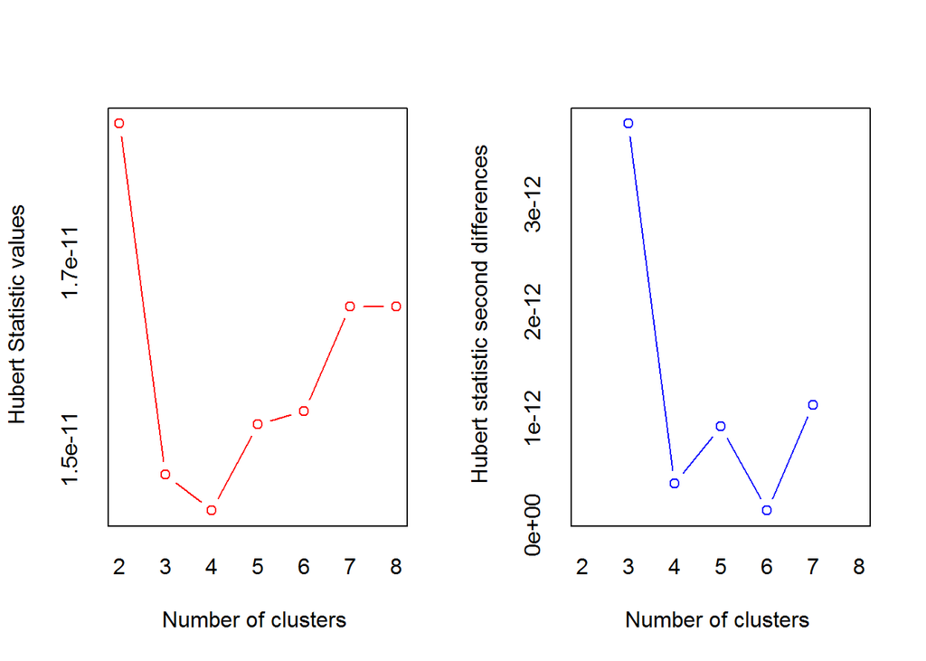

```
## *** : The Hubert index is a graphical method of determining the number of clusters.
##                 In the plot of Hubert index, we seek a significant knee that corresponds to a
##                 significant increase of the value of the measure i.e the significant peak in Hubert
##                 index second differences plot.
##
```

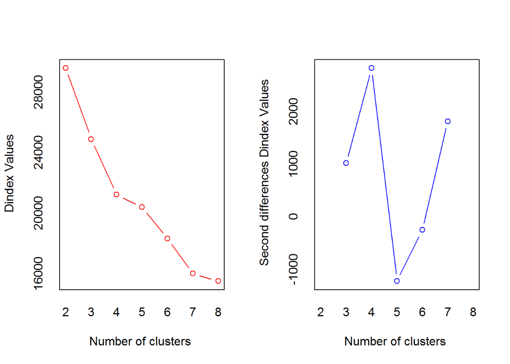

```
## *** : The D index is a graphical method of determining the number of clusters.
##                 In the plot of D index, we seek a significant knee (the significant peak in Dindex
##                 second differences plot) that corresponds to a significant increase of the value of
##                 the measure.
##
## * Among all indices:
## * 7 proposed 2 as the best number of clusters
## * 5 proposed 3 as the best number of clusters
## * 6 proposed 4 as the best number of clusters
## * 5 proposed 7 as the best number of clusters
## * 1 proposed 8 as the best number of clusters
##
##                    ***** Conclusion *****
##
## * According to the majority rule, the best number of clusters is  2
##
##
```

```r
a$All.index
```

```
##       KL      CH Hartigan      CCC    Scott      Marriot       TrCovW
## 2 0.9623 42.0468  47.0355   8.2676 1134.970 4.077845e+41 5.883741e+20
## 3 1.1501 53.1999  53.5088   8.3219 1260.730 2.924807e+41 3.104117e+20
## 4 7.4035 70.3752  10.5525   5.0749 1367.835 1.963849e+41 1.293333e+20
## 5 0.4130 60.1016  22.2228 -22.5093 1411.290 2.067113e+41 1.110118e+20
## 6 0.8227 62.1048  31.9254 -65.5070 1474.462 1.676151e+41 7.103676e+19
## 7 5.9864 72.2606   7.2261 -62.4494 1572.206 9.382121e+40 4.126977e+19
## 8 0.2065 66.6617  33.6651 -62.5697 1607.101 8.923056e+40 3.584771e+19
##         TraceW Friedman   Rubin Cindex     DB Silhouette   Duda Pseudot2
## 2 123960445557 3282.998  5.5417 0.2936 0.4225     0.6595 0.6935  46.4048
## 3  86352676429 3372.612  7.9552 0.3291 0.8638     0.3568 0.6060  55.9074
## 4  57565296154 3866.615 11.9335 0.3575 0.9028     0.3491 0.5666  13.0042
## 5  52353435986 3875.908 13.1215 0.3946 0.9630     0.3038 0.3048  43.3281
## 6  43208533363 3963.381 15.8986 0.3924 0.8495     0.2939 0.6740  31.4441
## 7  33059953027 4097.230 20.7791 0.3679 0.9710     0.2787 5.4006  -1.6297
```

[output cut: 17 more lines]

```r
a$Best.partition
```

```
##   [1] 1 1 1 1 1 2 2 1 1 1 1 1 1 1 1 1 1 1 1 1 1 1 1 1 1 1 1 1 1 1 1 1 1 1 1
##  [36] 1 1 1 1 1 1 1 1 1 1 1 1 1 1 1 1 1 1 1 1 1 1 1 1 1 1 1 1 1 1 1 2 1 1 1
##  [71] 1 1 1 1 1 1 1 1 1 1 1 1 1 1 1 1 1 1 1 1 1 1 1 1 1 1 1 1 1 1 1 1 1 1 1
## [106] 1 1 1 1 1
```

```r
b <- NbClust(w[,-c(1,14:15)],distance="euclidean",min.nc = 2,method="complete",index="all")
```

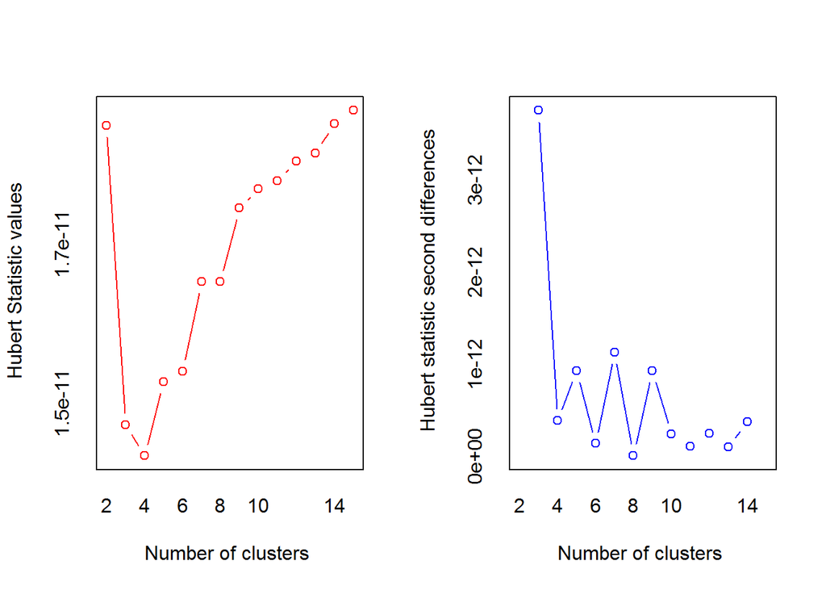

```
## *** : The Hubert index is a graphical method of determining the number of clusters.
##                 In the plot of Hubert index, we seek a significant knee that corresponds to a
##                 significant increase of the value of the measure i.e the significant peak in Hubert
##                 index second differences plot.
##
```

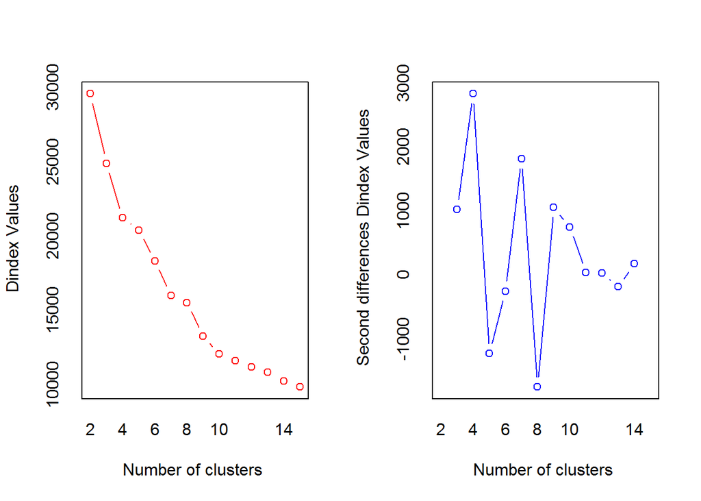

```
## *** : The D index is a graphical method of determining the number of clusters.
##                 In the plot of D index, we seek a significant knee (the significant peak in Dindex
##                 second differences plot) that corresponds to a significant increase of the value of
##                 the measure.
##
## * Among all indices:
## * 7 proposed 2 as the best number of clusters
## * 5 proposed 3 as the best number of clusters
## * 6 proposed 4 as the best number of clusters
## * 3 proposed 7 as the best number of clusters
## * 2 proposed 10 as the best number of clusters
## * 1 proposed 15 as the best number of clusters
##
##                    ***** Conclusion *****
##
## * According to the majority rule, the best number of clusters is  2
##
##
```